# Source memory performance for objects outside the rooms

# 1 Visual inspection of the data

# 2 Novelty Benefits

## 2.1 Check the data

**Is there any corrected hit rate < 0?**

There are 11 negative value out of a total of 80 values.

```
##     SubjectNo    Group MeanCurRt  MeanDur     SFHit       SHit     SrcHit
##  1:       P01 Familiar  3.666667      NaN 0.5000000 0.50000000 0.00000000
##  2:       P03    Novel  5.666667      NaN 0.4444444 0.11111111 0.11111111
##  3:       P11    Novel  4.666667      NaN 0.6111111 0.44444444 0.11111111
##  4:       P66    Novel  6.000000 20.53748 0.5000000 0.22222222 0.05555556
##  5:       P66 Familiar  1.666667 17.79574 0.4444444 0.11111111 0.11111111
##  6:       P71 Familiar  2.000000 25.45671 0.4444444 0.11111111 0.05555556
##  7:       P73 Familiar  2.000000 27.31160 0.4444444 0.05555556 0.00000000
##  8:       P75 Familiar  3.333333 31.98060 0.6666667 0.44444444 0.05555556
##  9:       P76 Familiar  2.333333 26.48253 0.4444444 0.27777778 0.05555556
## 10:       P79 Familiar  1.333333 30.32276 0.4444444 0.22222222 0.05555556
## 11:       P84    Novel  4.666667 23.98126 0.3888889 0.16666667 0.05555556
##        SFFalse     SFalse   SrcFalse       SFAcc        SAcc      SrcAcc
##  1: 0.11111111 0.00000000 0.01851852  0.38888889  0.50000000 -0.01851852
##  2: 0.38888889 0.05555556 0.12962963  0.05555556  0.05555556 -0.01851852
##  3: 0.55555556 0.50000000 0.18518519  0.05555556 -0.05555556 -0.07407407
##  4: 0.50000000 0.05555556 0.14814815  0.00000000  0.16666667 -0.09259259
##  5: 0.50000000 0.05555556 0.14814815 -0.05555556  0.05555556 -0.03703704
##  6: 0.38888889 0.16666667 0.14814815  0.05555556 -0.05555556 -0.09259259
##  7: 0.05555556 0.00000000 0.01851852  0.38888889  0.05555556 -0.01851852
##  8: 0.27777778 0.00000000 0.09259259  0.38888889  0.44444444 -0.03703704
##  9: 0.33333333 0.00000000 0.11111111  0.11111111  0.27777778 -0.05555556
## 10: 0.22222222 0.00000000 0.07407407  0.22222222  0.22222222 -0.01851852
## 11: 0.38888889 0.05555556 0.14814815  0.00000000  0.11111111 -0.09259259
```

## 2.2 Compare mean accuracy between *novel* and *familiar* rooms

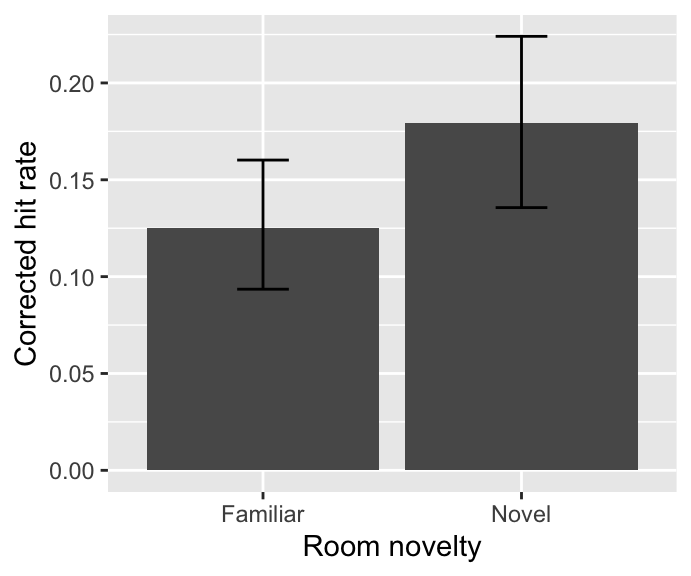

Figure1. Mean accuracy for item memory respectively for Familiar and Novel rooms.

```
##       Group      Mean        SD  N
## 1: Familiar 0.1250000 0.1101374 40
## 2:    Novel 0.1791667 0.1462598 40
```

```
##
##  Paired t-test
##
## data:  SrcAcc by Group
## t = -2.8349, df = 39, p-value = 0.007228
## alternative hypothesis: true difference in means is not equal to 0
## 95 percent confidence interval:
##  -0.09281483 -0.01551850
## sample estimates:
## mean of the differences
##             -0.05416667
```

## 2.3 Any difference between *Early* and *Later* object groups?

### 2.3.1 Check the data

**Is there any corrected hit rate < 0?**

There are 26 negative value out of a total of 160 values.

```
##     SubjectNo    Group ObjOrdGrp MeanCurRt  MeanDur     SFHit      SHit
##  1:       P01 Familiar     Early  3.666667      NaN 0.5555556 0.5555556
##  2:       P01    Novel     Later  6.000000      NaN 0.5555556 0.4444444
##  3:       P01 Familiar     Later  3.666667      NaN 0.4444444 0.4444444
##  4:       P03    Novel     Early  5.666667      NaN 0.3333333 0.1111111
##  5:       P10 Familiar     Later  1.666667      NaN 0.8888889 0.3333333
##  6:       P10    Novel     Later  6.000000      NaN 0.6666667 0.6666667
##  7:       P11    Novel     Early  4.666667      NaN 0.4444444 0.3333333
##  8:       P62    Novel     Early  6.000000 29.09068 0.3333333 0.2222222
##  9:       P62 Familiar     Later  3.000000 25.28234 0.4444444 0.2222222
## 10:       P66    Novel     Early  6.000000 20.53748 0.3333333 0.1111111
## 11:       P66    Novel     Later  6.000000 20.53748 0.6666667 0.3333333
## 12:       P66 Familiar     Early  1.666667 17.79574 0.2222222 0.1111111
## 13:       P71 Familiar     Early  2.000000 25.45671 0.2222222 0.0000000
## 14:       P71 Familiar     Later  2.000000 25.45671 0.6666667 0.2222222
```

[output cut: 69 more lines]

### 2.3.2 Analysis

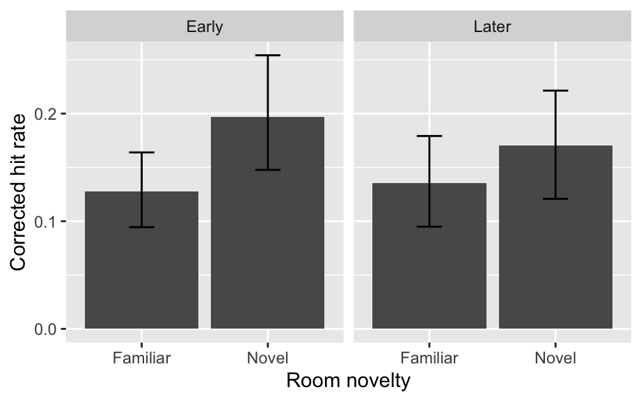

```
##       Group ObjOrdGrp      Mean        SD  N
## 1: Familiar     Early 0.1277778 0.1142944 40
## 2:    Novel     Early 0.1967593 0.1719224 40
## 3:    Novel     Later 0.1703704 0.1548349 40
## 4: Familiar     Later 0.1356481 0.1396788 40
```

```
## $ANOVA
##            Effect DFn DFd         F           p p<.05         ges
## 2           Group   1  39 7.6159163 0.008767679     * 0.031031838
## 3       ObjOrdGrp   1  39 0.2623613 0.611391228       0.001020184
## 4 Group:ObjOrdGrp   1  39 1.1157761 0.297329425       0.003482973
```

# 3 Curiosity Enhancement

## 3.1 Check the data

### 3.1.1 Is there any corrected hit rate < 0?

#### 3.1.1.1 For the data per room

- There are 63 negative values out of a total of 239 values.

```
##     SubjectNo     Context    Group CurRating RoomOrder Duration     SFHit
##  1:       P01     Bedroom Familiar         5     First       NA 0.3333333
##  2:       P01   Classroom Familiar         3    Second       NA 0.3333333
##  3:       P01         Gym Familiar         3    Second       NA 0.8333333
##  4:       P01     Library    Novel         4     First       NA 0.6666667
##  5:       P01 StorageRoom    Novel         7     First       NA 0.3333333
##  6:       P02     Bedroom Familiar         4    Second       NA 0.5000000
##  7:       P03         Gym Familiar         1    Second       NA 0.3333333
##  8:       P03     Library    Novel         7     First       NA 0.3333333
##  9:       P03  LivingRoom    Novel         7    Second       NA 0.1666667
## 10:       P04         Gym Familiar         5    Second       NA 0.6666667
## 11:       P06         Gym Familiar         3    Second       NA 0.6666667
## 12:       P06  LivingRoom    Novel         6     First       NA 0.1666667
## 13:       P08  LivingRoom    Novel         6     First       NA 0.1666667
## 14:       P09  LivingRoom    Novel         5    Second       NA 0.8333333
```

[output cut: 180 more lines]

#### 3.1.1.2 For the data per curiosity group

- There are 11 negative value for curiosity group (1 ~ 3 and 5 ~ 7) out of a total of 78 values.

```
##     SubjectNo CurGrp  MeanDur     SFHit       SHit     SrcHit    SFFalse
##  1:       P01    Low      NaN 0.5833333 0.58333333 0.00000000 0.11111111
##  2:       P03   High      NaN 0.2777778 0.00000000 0.05555556 0.38888889
##  3:       P11   High      NaN 0.3333333 0.22222222 0.11111111 0.55555556
##  4:       P66   High 20.53748 0.5000000 0.22222222 0.05555556 0.50000000
##  5:       P66    Low 17.79574 0.4444444 0.11111111 0.11111111 0.50000000
##  6:       P71    Low 25.45671 0.4444444 0.11111111 0.05555556 0.38888889
##  7:       P73    Low 27.31160 0.4444444 0.05555556 0.00000000 0.05555556
##  8:       P75    Low 31.09535 0.7500000 0.41666667 0.08333333 0.27777778
##  9:       P76    Low 26.80689 0.5000000 0.33333333 0.08333333 0.33333333
## 10:       P79    Low 30.32276 0.4444444 0.22222222 0.05555556 0.22222222
## 11:       P84   High 23.84103 0.4166667 0.08333333 0.08333333 0.38888889
##         SFalse   SrcFalse       SFAcc        SAcc       SrcAcc
##  1: 0.00000000 0.01851852  0.47222222  0.58333333 -0.018518519
##  2: 0.05555556 0.12962963 -0.11111111 -0.05555556 -0.074074074
##  3: 0.50000000 0.18518519 -0.22222222 -0.27777778 -0.074074074
##  4: 0.05555556 0.14814815  0.00000000  0.16666667 -0.092592593
##  5: 0.05555556 0.14814815 -0.05555556  0.05555556 -0.037037037
##  6: 0.16666667 0.14814815  0.05555556 -0.05555556 -0.092592593
##  7: 0.00000000 0.01851852  0.38888889  0.05555556 -0.018518519
##  8: 0.00000000 0.09259259  0.47222222  0.41666667 -0.009259259
##  9: 0.00000000 0.11111111  0.16666667  0.33333333 -0.027777778
## 10: 0.00000000 0.07407407  0.22222222  0.22222222 -0.018518519
## 11: 0.05555556 0.14814815  0.02777778  0.02777778 -0.064814815
```

#### 3.1.1.3 For the data per curiosity group (median)

- There are 11 negative value for curiosity group (median) out of a total of 79 values.

```
##     SubjectNo CurGrpMedian  MeanDur     SFHit       SHit     SrcHit
##  1:       P01          Low      NaN 0.6111111 0.55555556 0.00000000
##  2:       P03         High      NaN 0.2777778 0.00000000 0.05555556
##  3:       P11         High      NaN 0.3333333 0.22222222 0.11111111
##  4:       P66         High 20.53748 0.5000000 0.22222222 0.05555556
##  5:       P66          Low 17.79574 0.4444444 0.11111111 0.11111111
##  6:       P71          Low 25.45671 0.4444444 0.11111111 0.05555556
##  7:       P73          Low 27.31160 0.4444444 0.05555556 0.00000000
##  8:       P75          Low 31.98060 0.6666667 0.44444444 0.05555556
##  9:       P76          Low 26.80689 0.5000000 0.33333333 0.08333333
## 10:       P79          Low 30.32276 0.4444444 0.22222222 0.05555556
## 11:       P84         High 23.98126 0.3888889 0.16666667 0.05555556
##        SFFalse     SFalse   SrcFalse       SFAcc        SAcc      SrcAcc
##  1: 0.11111111 0.00000000 0.01851852  0.50000000  0.55555556 -0.01851852
##  2: 0.38888889 0.05555556 0.12962963 -0.11111111 -0.05555556 -0.07407407
##  3: 0.55555556 0.50000000 0.18518519 -0.22222222 -0.27777778 -0.07407407
##  4: 0.50000000 0.05555556 0.14814815  0.00000000  0.16666667 -0.09259259
##  5: 0.50000000 0.05555556 0.14814815 -0.05555556  0.05555556 -0.03703704
##  6: 0.38888889 0.16666667 0.14814815  0.05555556 -0.05555556 -0.09259259
##  7: 0.05555556 0.00000000 0.01851852  0.38888889  0.05555556 -0.01851852
##  8: 0.27777778 0.00000000 0.09259259  0.38888889  0.44444444 -0.03703704
##  9: 0.33333333 0.00000000 0.11111111  0.16666667  0.33333333 -0.02777778
## 10: 0.22222222 0.00000000 0.07407407  0.22222222  0.22222222 -0.01851852
## 11: 0.38888889 0.05555556 0.14814815  0.00000000  0.11111111 -0.09259259
```

## 3.2 Mean accuracy of item memory as a function of curiosity rating

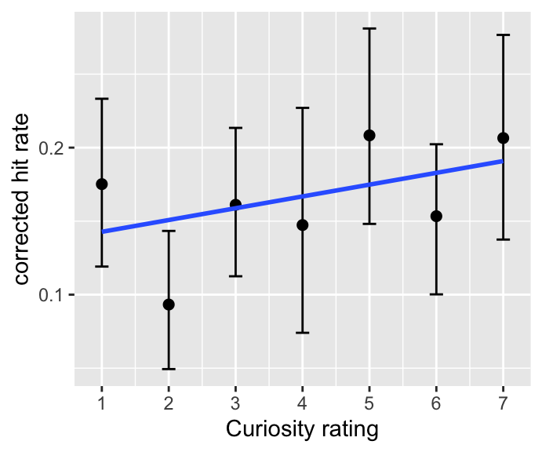

## 3.3 Testing the relationship between mean accuracy of item memory and curiosity rating

Build models with item memory accuracy as $y$ and examine effects of curiosity rating by including it into the model and then comparing the model fits.

- `baseline.rating` is the model with only an intercept, showing no change in item memory as a function of curiosity rating.
- `rating.intercept` is the model with $\small CuriosityRating$ included, showing the effects of curiosity rating.
- `rating.slope` is the model allowing the slope (i.e., relationship between item memory and curiosity rating) varying across participants.

```
##                  Model df       AIC       BIC   logLik   Test   L.Ratio
## baseline.rating      1  3 -138.3763 -127.9469 72.18816
## rating.intercept     2  4 -139.2815 -125.3756 73.64073 1 vs 2 2.9051409
## rating.slope         3  6 -136.0489 -115.1901 74.02446 2 vs 3 0.7674508
##                  p-value
## baseline.rating
## rating.intercept  0.0883
## rating.slope      0.6813
```

```
## Linear mixed-effects model fit by maximum likelihood
##  Data: outside.hit.rate.per.room
##         AIC       BIC   logLik
##   -136.0489 -115.1901 74.02446
##
## Random effects:
##  Formula: ~1 + CurRating | SubjectNo
##  Structure: General positive-definite, Log-Cholesky parametrization
##             StdDev     Corr
## (Intercept) 0.06111211 (Intr)
## CurRating   0.00710189 0.589
## Residual    0.16422430
##
## Fixed effects: SrcAcc ~ CurRating
##                  Value   Std.Error  DF  t-value p-value
## (Intercept) 0.13219409 0.026201080 198 5.045368  0.0000
## CurRating   0.00873586 0.005526621 198 1.580688  0.1155
##  Correlation:
##           (Intr)
## CurRating -0.773
##
## Standardized Within-Group Residuals:
##        Min         Q1        Med         Q3        Max
## -1.7627563 -0.6642181 -0.3062926  0.5662563  4.2406942
##
## Number of Observations: 239
## Number of Groups: 40
```

## 3.4 Check the curiosity groups

### 3.4.1 Separate the groups according to the rating

- *High*: curiosity rating > 4
- *Low*: curiosity rating < 4
- For curiosity rating = 4, discarded

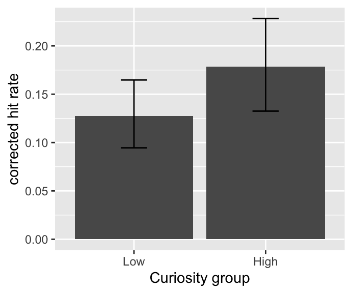

```
##    CurGrp      Mean        SD  N
## 1:    Low 0.1273148 0.1156168 38
## 2:   High 0.1783333 0.1546655 40
```

```
## Linear mixed-effects model fit by maximum likelihood
##  Data: outside.hit.rate.curiosity.group[!is.na(CurGrp)]
##         AIC       BIC   logLik
##   -97.74988 -83.60963 54.87494
##
## Random effects:
##  Formula: ~1 + CurGrp | SubjectNo
##  Structure: General positive-definite, Log-Cholesky parametrization
##             StdDev     Corr
## (Intercept) 0.10349145 (Intr)
## CurGrpHigh  0.10787403 -0.056
## Residual    0.04728863
##
## Fixed effects: SrcAcc ~ CurGrp
##                  Value  Std.Error DF  t-value p-value
## (Intercept) 0.12540655 0.01854144 39 6.763583  0.0000
## CurGrpHigh  0.05292678 0.02061381 37 2.567540  0.0144
##  Correlation:
##            (Intr)
## CurGrpHigh -0.223
##
## Standardized Within-Group Residuals:
##         Min          Q1         Med          Q3         Max
## -0.95982061 -0.33178334 -0.04572658  0.24997574  1.28819424
##
## Number of Observations: 78
## Number of Groups: 40
```

#### 3.4.1.1 Curiosity groups and temporal order of the objects

##### 3.4.1.1.1 Check the data

**Is there any corrected hit rate < 0?**

```
##     SubjectNo CurGrp ObjOrdGrp     SFHit      SHit     SrcHit    SFFalse
##  1:       P01    Low     Early 0.6666667 0.6666667 0.00000000 0.11111111
##  2:       P01   High     Later 0.4444444 0.4444444 0.00000000 0.11111111
##  3:       P01    Low     Later 0.5000000 0.5000000 0.00000000 0.11111111
##  4:       P02    Low     Later 0.6666667 0.3333333 0.00000000 0.16666667
##  5:       P02   High     Later 0.6666667 0.6666667 0.00000000 0.16666667
##  6:       P03   High     Early 0.3333333 0.0000000 0.11111111 0.38888889
##  7:       P03   High     Later 0.2222222 0.0000000 0.00000000 0.38888889
##  8:       P03    Low     Early 0.3333333 0.1666667 0.00000000 0.38888889
##  9:       P06   High     Early 0.3333333 0.0000000 0.00000000 0.27777778
## 10:       P06    Low     Later 0.6666667 0.3333333 0.00000000 0.27777778
## 11:       P10    Low     Later 0.8888889 0.3333333 0.11111111 0.50000000
## 12:       P10   High     Later 0.6666667 0.6666667 0.11111111 0.50000000
## 13:       P11   High     Later 0.4444444 0.2222222 0.11111111 0.55555556
## 14:       P11   High     Early 0.2222222 0.2222222 0.11111111 0.55555556
```

[output cut: 53 more lines]

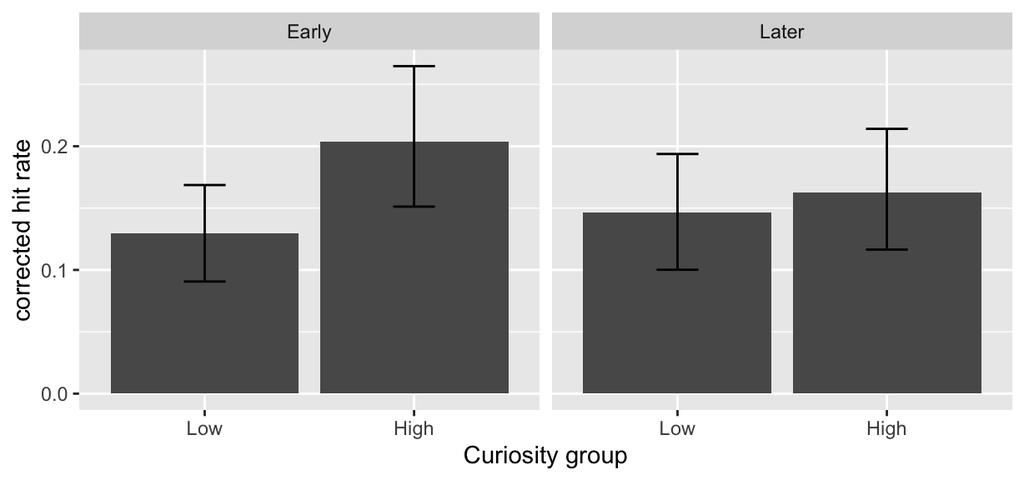

```
##    CurGrp ObjOrdGrp      Mean        SD  N
## 1:    Low     Early 0.1298733 0.1209079 38
## 2:   High     Early 0.2036111 0.1878825 40
## 3:   High     Later 0.1625463 0.1561477 40
## 4:    Low     Later 0.1461988 0.1500775 38
```

```
##           Model df       AIC       BIC   logLik   Test  L.Ratio p-value
## baseline      1  8 -151.9057 -127.5068 83.95284
## ord.model     2  9 -150.1138 -122.6651 84.05690 1 vs 2 0.208111  0.6483
## cur.model     3 10 -152.7333 -122.2348 86.36666 2 vs 3 4.619525  0.0316
## int.model     4 11 -153.3392 -119.7908 87.66961 3 vs 4 2.605899  0.1065
```

```
## Linear mixed-effects model fit by maximum likelihood
##  Data: outside.hit.rate.item.order.curiosity[!is.na(CurGrp)]
##         AIC       BIC   logLik
##   -153.3392 -119.7908 87.66961
##
## Random effects:
##  Formula: ~1 + CurGrp + ObjOrdGrp | SubjectNo
##  Structure: General positive-definite, Log-Cholesky parametrization
##                StdDev     Corr
## (Intercept)    0.07113457 (Intr) CrGrpH
## CurGrpHigh     0.06991569  0.700
## ObjOrdGrpLater 0.03958941  0.112 -0.542
## Residual       0.11060785
##
## Fixed effects: SrcAcc ~ ObjOrdGrp + CurGrp + ObjOrdGrp:CurGrp
##                                 Value  Std.Error  DF   t-value p-value
## (Intercept)                0.12818135 0.02150539 113  5.960428  0.0000
## ObjOrdGrpLater             0.01684992 0.02651488 113  0.635489  0.5264
## CurGrpHigh                 0.07542976 0.02778438 113  2.714826  0.0077
## ObjOrdGrpLater:CurGrpHigh -0.05791474 0.03592530 113 -1.612088  0.1097
##  Correlation:
##                           (Intr) ObjOGL CrGrpH
## ObjOrdGrpLater            -0.564
## CurGrpHigh                -0.407  0.395
## ObjOrdGrpLater:CurGrpHigh  0.427 -0.696 -0.645
##
## Standardized Within-Group Residuals:
##        Min         Q1        Med         Q3        Max
## -1.5037354 -0.6671875 -0.2021246  0.6384351  2.6442464
##
## Number of Observations: 156
## Number of Groups: 40
```

##### 3.4.1.1.2 *Post hoc*

```
##
##   Simultaneous Tests for General Linear Hypotheses
##
## Fit: lme.formula(fixed = SrcAcc ~ ObjOrdGrp + CurGrp + ObjOrdGrp:CurGrp,
##     data = outside.hit.rate.item.order.curiosity[!is.na(CurGrp)],
##     random = ~1 + CurGrp + ObjOrdGrp | SubjectNo, method = "ML",
##     na.action = na.exclude, control = list(msMaxIter = 500, opt = "optim",
##         msVerbose = FALSE))
##
## Linear Hypotheses:
##                          Estimate Std. Error z value Pr(>|z|)
## Early: High vs. Low == 0  0.07543    0.02743   2.750  0.00595 **
## Late:  High vs. Low == 0  0.01752    0.02748   0.637  0.52392
## ---
## Signif. codes:  0 '***' 0.001 '**' 0.01 '*' 0.05 '.' 0.1 ' ' 1
## (Adjusted p values reported -- none method)
```

### 3.4.2 Separate the groups according to the median rating of each participant

- *High*: curiosity rating > median of the participant
- *Low*: curiosity rating < median of the participant

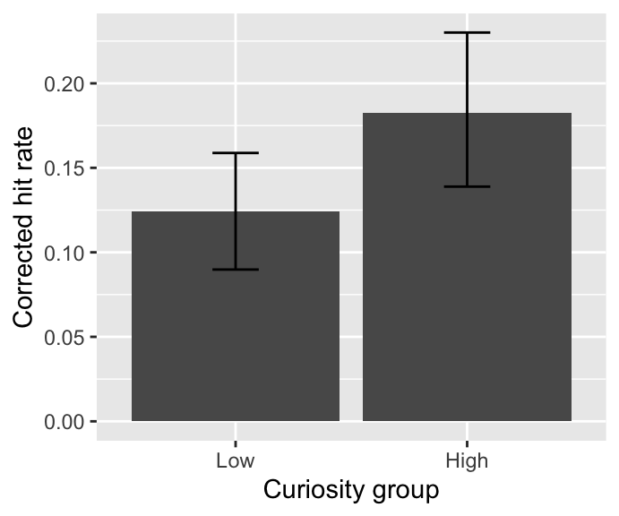

```
## Linear mixed-effects model fit by maximum likelihood
##  Data: outside.hit.rate.curiosity.group.median[!is.na(CurGrpMedian)]
##         AIC       BIC   logLik
##   -101.7812 -87.56448 56.89058
##
## Random effects:
##  Formula: ~1 + CurGrpMedian | SubjectNo
##  Structure: General positive-definite, Log-Cholesky parametrization
##                  StdDev     Corr
## (Intercept)      0.10015047 (Intr)
## CurGrpMedianHigh 0.11047402 -0.093
## Residual         0.04698844
##
## Fixed effects: SrcAcc ~ CurGrpMedian
##                       Value  Std.Error DF  t-value p-value
## (Intercept)      0.12430556 0.01771715 39 7.016113  0.0000
## CurGrpMedianHigh 0.05830578 0.02089665 38 2.790197  0.0082
##  Correlation:
##                  (Intr)
## CurGrpMedianHigh -0.224
##
## Standardized Within-Group Residuals:
##         Min          Q1         Med          Q3         Max
## -0.88874323 -0.28754909 -0.01858409  0.25848054  1.29559938
##
## Number of Observations: 79
## Number of Groups: 40
```

#### 3.4.2.1 Curiosity groups and temporal order of the objects

##### 3.4.2.1.1 Check the data

```
##     SubjectNo CurGrpMedian ObjOrdGrp     SFHit      SHit    SrcHit
##  1:       P01          Low     Early 0.6666667 0.6666667 0.0000000
##  2:       P01          Low     Later 0.5555556 0.4444444 0.0000000
##  3:       P01         High     Later 0.4444444 0.4444444 0.0000000
##  4:       P02          Low     Later 0.6666667 0.3333333 0.0000000
##  5:       P02         High     Later 0.6666667 0.6666667 0.0000000
##  6:       P03         High     Early 0.3333333 0.0000000 0.1111111
##  7:       P03         High     Later 0.2222222 0.0000000 0.0000000
##  8:       P06         High     Early 0.3333333 0.0000000 0.0000000
##  9:       P06          Low     Later 0.6666667 0.3333333 0.0000000
## 10:       P07          Low     Early 0.8333333 0.0000000 0.0000000
## 11:       P10          Low     Later 0.8888889 0.3333333 0.1111111
## 12:       P10         High     Later 0.6666667 0.6666667 0.1111111
## 13:       P11         High     Later 0.4444444 0.2222222 0.1111111
## 14:       P11          Low     Early 0.7777778 0.6666667 0.1111111
```

[output cut: 59 more lines]

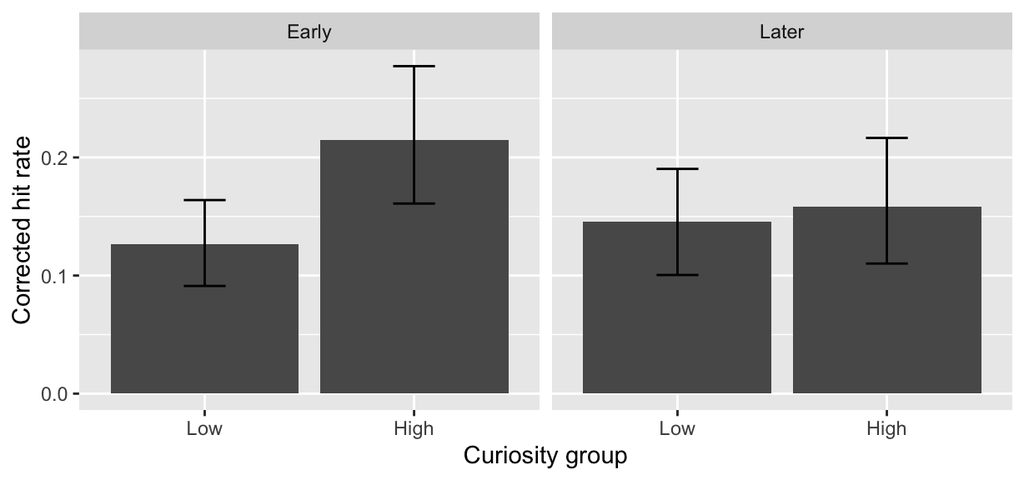

```
##    CurGrpMedian ObjOrdGrp      Mean        SD  N
## 1:          Low     Early 0.1268519 0.1216547 40
## 2:          Low     Later 0.1453704 0.1504189 40
## 3:         High     Early 0.2150997 0.1923382 39
## 4:         High     Later 0.1585945 0.1594606 39
```

```
##           Model df       AIC       BIC   logLik   Test  L.Ratio p-value
## baseline      1  8 -143.9441 -119.4433 79.97203
## ord.model     2  9 -141.9900 -114.4267 79.99501 1 vs 2 0.045957  0.8303
## cur.model     3 10 -145.4839 -114.8580 82.74195 2 vs 3 5.493889  0.0191
## int.model     4 11 -147.8388 -114.1502 84.91938 3 vs 4 4.354848  0.0369
```

```
## Linear mixed-effects model fit by maximum likelihood
##  Data: outside.hit.rate.item.order.curiosity.median[!is.na(CurGrpMedian)]
##         AIC       BIC   logLik
##   -147.8388 -114.1502 84.91938
##
## Random effects:
##  Formula: ~1 + CurGrpMedian + ObjOrdGrp | SubjectNo
##  Structure: General positive-definite, Log-Cholesky parametrization
##                  StdDev     Corr
## (Intercept)      0.08605432 (Intr) CrGrMH
## CurGrpMedianHigh 0.07486282  0.645
## ObjOrdGrpLater   0.09967365 -0.519 -0.489
## Residual         0.10591269
##
## Fixed effects: SrcAcc ~ ObjOrdGrp + CurGrpMedian + ObjOrdGrp:CurGrpMedian
##                                       Value  Std.Error  DF   t-value
## (Intercept)                      0.12685185 0.02185552 115  5.804110
## ObjOrdGrpLater                   0.01851852 0.02881432 115  0.642684
## CurGrpMedianHigh                 0.08680261 0.02712531 115  3.200059
## ObjOrdGrpLater:CurGrpMedianHigh -0.07206542 0.03420763 115 -2.106706
##                                 p-value
## (Intercept)                      0.0000
## ObjOrdGrpLater                   0.5217
## CurGrpMedianHigh                 0.0018
## ObjOrdGrpLater:CurGrpMedianHigh  0.0373
##  Correlation:
##                                 (Intr) ObjOGL CrGrMH
## ObjOrdGrpLater                  -0.638
## CurGrpMedianHigh                -0.305  0.248
## ObjOrdGrpLater:CurGrpMedianHigh  0.385 -0.584 -0.632
##
## Standardized Within-Group Residuals:
##        Min         Q1        Med         Q3        Max
## -2.0897305 -0.6007489 -0.1455365  0.5738221  2.3770111
##
## Number of Observations: 158
## Number of Groups: 40
```

##### 3.4.2.1.2 *Post hoc*

```
##
##   Simultaneous Tests for General Linear Hypotheses
##
## Fit: lme.formula(fixed = SrcAcc ~ ObjOrdGrp + CurGrpMedian + ObjOrdGrp:CurGrpMedian,
##     data = outside.hit.rate.item.order.curiosity.median[!is.na(CurGrpMedian)],
##     random = ~1 + CurGrpMedian + ObjOrdGrp | SubjectNo, method = "ML",
##     na.action = na.exclude, control = list(msMaxIter = 500, opt = "optim",
##         msVerbose = FALSE))
##
## Linear Hypotheses:
##                          Estimate Std. Error z value Pr(>|z|)
## Early: High vs. Low == 0  0.08680    0.02678   3.241  0.00119 **
## Late:  High vs. Low == 0  0.01474    0.02672   0.552  0.58129
## ---
## Signif. codes:  0 '***' 0.001 '**' 0.01 '*' 0.05 '.' 0.1 ' ' 1
## (Adjusted p values reported -- none method)
```

# 4 **Novelty** or **Curiosity**?

## 4.1 For Curiosity group splitted by score (*Low*: 1 ~ 3; *High*: 5 ~ 7)

### 4.1.1 Curiosity first, novelty next

```
##               Model df       AIC       BIC   logLik   Test  L.Ratio
## base.model        1  8 -123.8265 -96.82432 69.91327
## cur.scr.model     2  9 -125.5809 -95.20338 71.79044 1 vs 2 3.754342
## nov.scr.model     3 10 -125.8196 -92.06677 72.90978 2 vs 3 2.238666
##               p-value
## base.model
## cur.scr.model  0.0527
## nov.scr.model  0.1346
```

```
## Linear mixed-effects model fit by maximum likelihood
##  Data: outside.hit.rate.per.room[!is.na(CurGrp)]
##         AIC       BIC   logLik
##   -125.5809 -95.20338 71.79044
##
## Random effects:
##  Formula: ~1 + CurGrp + Group | SubjectNo
##  Structure: General positive-definite, Log-Cholesky parametrization
##             StdDev       Corr
## (Intercept) 0.1093421315 (Intr) CrGrpL
## CurGrpLow   0.0411219814 -0.989
## GroupNovel  0.0001317806 -0.002  0.002
## Residual    0.1576048812
##
## Fixed effects: SrcAcc ~ CurGrp
##                   Value  Std.Error  DF   t-value p-value
## (Intercept)  0.18933940 0.02309780 175  8.197292  0.0000
## CurGrpLow   -0.04471552 0.02294022 175 -1.949219  0.0529
##  Correlation:
##           (Intr)
## CurGrpLow -0.654
##
## Standardized Within-Group Residuals:
##        Min         Q1        Med         Q3        Max
## -1.9915286 -0.6589553 -0.2826983  0.6002495  3.8472265
##
## Number of Observations: 216
## Number of Groups: 40
```

### 4.1.2 Novelty first, curiosity next

```
##               Model df       AIC       BIC   logLik   Test  L.Ratio
## base.model        1  8 -123.8265 -96.82432 69.91327
## nov.scr.model     2  9 -127.8296 -97.45210 72.91480 1 vs 2 6.003066
## cur.scr.model     3 10 -125.8196 -92.06677 72.90978 2 vs 3 0.010058
##               p-value
## base.model
## nov.scr.model  0.0143
## cur.scr.model  0.9201
```

```
## Linear mixed-effects model fit by maximum likelihood
##  Data: outside.hit.rate.per.room[!is.na(CurGrp)]
##         AIC      BIC  logLik
##   -127.8296 -97.4521 72.9148
##
## Random effects:
##  Formula: ~1 + CurGrp + Group | SubjectNo
##  Structure: General positive-definite, Log-Cholesky parametrization
##             StdDev       Corr
## (Intercept) 0.1082782188 (Intr) CrGrpL
## CurGrpLow   0.0401449141 -0.985
## GroupNovel  0.0001648329 -0.001  0.002
## Residual    0.1568077591
##
## Fixed effects: SrcAcc ~ Group
##                  Value  Std.Error  DF  t-value p-value
## (Intercept) 0.14016467 0.01917555 175 7.309550  0.0000
## GroupNovel  0.05489041 0.02222244 175 2.470044  0.0145
##  Correlation:
##            (Intr)
## GroupNovel -0.42
##
## Standardized Within-Group Residuals:
##        Min         Q1        Med         Q3        Max
## -2.0486600 -0.6562260 -0.2848697  0.5762269  3.8477036
##
## Number of Observations: 216
## Number of Groups: 40
```

## 4.2 For Curiosity group splitted by individual medians

### 4.2.1 Curiosity first, novelty next

```
##              Model df       AIC       BIC   logLik   Test  L.Ratio p-value
## base.model       1  8 -117.8949 -90.53067 66.94748
## cur.md.model     2  9 -120.2278 -89.44294 69.11388 1 vs 2 4.332806  0.0374
## nov.md.model     3 10 -118.2818 -84.07647 69.14091 2 vs 3 0.054068  0.8161
```

```
## Linear mixed-effects model fit by maximum likelihood
##  Data: outside.hit.rate.per.room[!is.na(CurGrpMedian)]
##         AIC       BIC   logLik
##   -120.2278 -89.44294 69.11388
##
## Random effects:
##  Formula: ~1 + CurGrpMedian + Group | SubjectNo
##  Structure: General positive-definite, Log-Cholesky parametrization
##                 StdDev       Corr
## (Intercept)     0.1079768428 (Intr) CrGrML
## CurGrpMedianLow 0.0482016619 -0.987
## GroupNovel      0.0005197947 -0.002  0.003
## Residual        0.1638095915
##
## Fixed effects: SrcAcc ~ CurGrpMedian
##                       Value  Std.Error  DF   t-value p-value
## (Intercept)      0.19272739 0.02334536 185  8.255489  0.0000
## CurGrpMedianLow -0.04880582 0.02329447 185 -2.095167  0.0375
##  Correlation:
##                 (Intr)
## CurGrpMedianLow -0.695
##
## Standardized Within-Group Residuals:
##        Min         Q1        Med         Q3        Max
## -1.8806753 -0.6465381 -0.2982116  0.5639667  3.8591155
##
## Number of Observations: 226
## Number of Groups: 40
```

### 4.2.2 Novelty first, curiosity next

```
##              Model df       AIC       BIC   logLik   Test  L.Ratio p-value
## base.model       1  8 -117.8949 -90.53067 66.94748
## nov.md.model     2  9 -119.2941 -88.50924 68.64703 1 vs 2 3.399107  0.0652
## cur.md.model     3 10 -118.2818 -84.07647 69.14091 2 vs 3 0.987766  0.3203
```

```
## Linear mixed-effects model fit by maximum likelihood
##  Data: outside.hit.rate.per.room[!is.na(CurGrpMedian)]
##         AIC       BIC   logLik
##   -119.2941 -88.50924 68.64703
##
## Random effects:
##  Formula: ~1 + CurGrpMedian + Group | SubjectNo
##  Structure: General positive-definite, Log-Cholesky parametrization
##                 StdDev       Corr
## (Intercept)     0.1067127874 (Intr) CrGrML
## CurGrpMedianLow 0.0455021457 -0.992
## GroupNovel      0.0000588955  0.002 -0.002
## Residual        0.1643111459
##
## Fixed effects: SrcAcc ~ Group
##                  Value  Std.Error  DF  t-value p-value
## (Intercept) 0.14457613 0.01857542 185 7.783196  0.0000
## GroupNovel  0.04274586 0.02291072 185 1.865758  0.0637
##  Correlation:
##            (Intr)
## GroupNovel -0.42
##
## Standardized Within-Group Residuals:
##        Min         Q1        Med         Q3        Max
## -1.8727997 -0.6724836 -0.2983157  0.5545595  3.8818916
##
## Number of Observations: 226
## Number of Groups: 40
```

## 4.3 For mean curiosity ratings for the *novel* and *familiar* rooms respectively

### 4.3.1 Curiosity first, novelty next

```r
basic <- lme(SrcAcc ~ 1, random = ~ 1 + Group|SubjectNo, data = outside.hit.rate.novelty.group, method = "ML", control = list(msMaxIter = 500, opt = "optim", msVerbose=FALSE), na.action = na.exclude)

cur.m <- update(basic, .~. + MeanCurRt)
nov.m <- update(cur.m, .~. + Group)

anova(basic, cur.m, nov.m)
```

```
##       Model df       AIC       BIC   logLik   Test  L.Ratio p-value
## basic     1  5 -104.6867 -92.77660 57.34337
## cur.m     2  6 -112.1176 -97.82543 62.05880 1 vs 2 9.430859  0.0021
## nov.m     3  7 -110.1647 -93.49055 62.08237 2 vs 3 0.047143  0.8281
```

```
##                  Value   Std.Error DF  t-value     p-value
## (Intercept) 0.08195550 0.023726549 39 3.454168 0.001344739
## MeanCurRt   0.01713201 0.005193352 39 3.298835 0.002079104
```

### 4.3.2 Novelty first, curiosity next

```r
nov.m <- update(basic, .~. + Group)
cur.m <- update(nov.m, .~. + MeanCurRt)

anova(basic, nov.m, cur.m)
```

```
##       Model df       AIC       BIC   logLik   Test  L.Ratio p-value
## basic     1  5 -104.6867 -92.77660 57.34337
## nov.m     2  6 -110.1812 -95.88904 61.09060 1 vs 2 7.494468  0.0062
## cur.m     3  7 -110.1647 -93.49055 62.08237 2 vs 3 1.983534  0.1590
```

```
##                   Value  Std.Error DF   t-value    p-value
## (Intercept) 0.086668339 0.03201239 39 2.7073370 0.01001457
## GroupNovel  0.008017365 0.03695757 38 0.2169343 0.82942007
## MeanCurRt   0.015130919 0.01050268 38 1.4406717 0.15786692
```

### 4.3.3 Testing mediation effect

```
## Linear mixed-effects model fit by maximum likelihood
##  Data: outside.hit.rate.novelty.group
##         AIC       BIC  logLik
##   -110.1812 -95.88904 61.0906
##
## Random effects:
##  Formula: ~1 + Group | SubjectNo
##  Structure: General positive-definite, Log-Cholesky parametrization
##             StdDev     Corr
## (Intercept) 0.09895582 (Intr)
## GroupNovel  0.10084146 -0.057
## Residual    0.04510803
##
## Fixed effects: SrcAcc ~ Group
##                  Value  Std.Error DF  t-value p-value
## (Intercept) 0.12500000 0.01741425 39 7.178029  0.0000
## GroupNovel  0.05416667 0.01910730 39 2.834868  0.0072
##  Correlation:
##            (Intr)
## GroupNovel -0.201
##
## Standardized Within-Group Residuals:
##          Min           Q1          Med           Q3          Max
## -1.026987776 -0.302983772  0.001219703  0.242664414  1.365221077
##
## Number of Observations: 80
## Number of Groups: 40
```

```
## Linear mixed-effects model fit by maximum likelihood
##  Data: outside.hit.rate.novelty.group
##        AIC      BIC    logLik
##   225.0397 239.3319 -106.5199
##
## Random effects:
##  Formula: ~1 + Group | SubjectNo
##  Structure: General positive-definite, Log-Cholesky parametrization
##             StdDev    Corr
## (Intercept) 0.9679134 (Intr)
## GroupNovel  1.3748097 -0.886
## Residual    0.4482426
##
## Fixed effects: MeanCurRt ~ Group
##                Value Std.Error DF  t-value p-value
## (Intercept) 2.533333 0.1708034 39 14.83187       0
## GroupNovel  3.050000 0.2424207 39 12.58143       0
##  Correlation:
##            (Intr)
## GroupNovel -0.854
##
## Standardized Within-Group Residuals:
##         Min          Q1         Med          Q3         Max
## -1.35136084 -0.30076611  0.01271869  0.32197129  1.25853207
##
## Number of Observations: 80
## Number of Groups: 40
```

```
## Linear mixed-effects model fit by maximum likelihood
##  Data: outside.hit.rate.novelty.group
##         AIC       BIC   logLik
##   -110.1647 -93.49055 62.08237
##
## Random effects:
##  Formula: ~1 + Group | SubjectNo
##  Structure: General positive-definite, Log-Cholesky parametrization
##             StdDev     Corr
## (Intercept) 0.10111073 (Intr)
## GroupNovel  0.09553808 -0.044
## Residual    0.04445423
##
## Fixed effects: SrcAcc ~ MeanCurRt + Group
##                  Value  Std.Error DF   t-value p-value
## (Intercept) 0.08666834 0.03201239 39 2.7073370  0.0100
## MeanCurRt   0.01513092 0.01050268 38 1.4406717  0.1579
## GroupNovel  0.00801736 0.03695757 38 0.2169343  0.8294
##  Correlation:
##            (Intr) MnCrRt
## MeanCurRt  -0.831
## GroupNovel  0.668 -0.867
##
## Standardized Within-Group Residuals:
##           Min            Q1           Med            Q3           Max
## -1.0692860555 -0.3456546758 -0.0002657184  0.2904669839  1.3158621768
##
## Number of Observations: 80
## Number of Groups: 40
```

```r
library(RMediation)
```

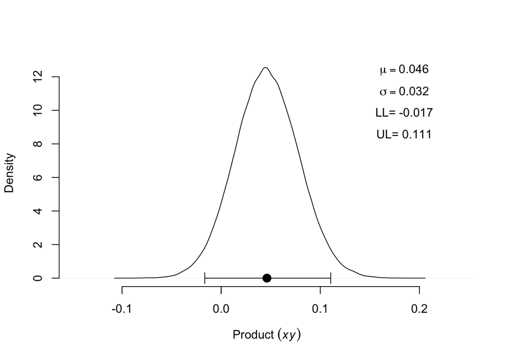

[output not shown]

```r
a = summary(fit.2)$tTable[2, 1]
se.a = summary(fit.2)$tTable[2,2]
b = summary(fit.3)$tTable[2,1]
se.b = summary(fit.3)$tTable[2,2]

medci(mu.x=a, mu.y=b, se.x=se.a, se.y=se.b, rho=0, alpha=.05, type="prodclin", plot=TRUE, plotCI=TRUE)
```